# Beer Recipes and Styles

Derek Pickern

04.17.2018

## Abstract

I explore homebrew beer recipes and the context of styles and ingredients. My goal is to explore patterns in beer styles to better understand how styles of beers are trending and how our palettes are changing.

## Introduction

Kaggle.com has a wide variety of datasets for public consumption (mostly public, there are some private datasets). The beer data was downloaded from: https://www.kaggle.com/jtrofe/beer-recipes/data. The data consists of over 75,000 homebrew recipes from Brewer’s Friend. This data was initially in two separate .csv’s. One .csv for recipe information (Name, Size, Original Gravity…), the other for beer-style (Lager, Ale, Stout, etc…). The two sets were merged on ‘StyleID’.

```r
summary(df)
```

```
##     Style              StyleID           BeerID          Name
##  Length:73861       Min.   :  1.00   Min.   :    1   Length:73861
##  Class :character   1st Qu.: 10.00   1st Qu.:18466   Class :character
##  Mode  :character   Median : 35.00   Median :36931   Mode  :character
##                     Mean   : 60.18   Mean   :36931
##                     3rd Qu.:111.00   3rd Qu.:55396
##                     Max.   :176.00   Max.   :73861
##
##      URL               Size(L)              OG               FG
##  Length:73861       Min.   :   1.00   Min.   : 1.000   Min.   :-0.003
##  Class :character   1st Qu.:  18.93   1st Qu.: 1.051   1st Qu.: 1.011
##  Mode  :character   Median :  20.82   Median : 1.058   Median : 1.013
##                     Mean   :  43.93   Mean   : 1.406   Mean   : 1.076
##                     3rd Qu.:  23.66   3rd Qu.: 1.069   3rd Qu.: 1.017
##                     Max.   :9200.00   Max.   :34.035   Max.   :23.425
##
##       ABV              IBU              Color           BoilSize
##  Min.   : 0.000   Min.   :   0.00   Min.   :  0.00   Min.   :   1.00
##  1st Qu.: 5.080   1st Qu.:  23.37   1st Qu.:  5.17   1st Qu.:  20.82
##  Median : 5.790   Median :  35.77   Median :  8.44   Median :  27.44
##  Mean   : 6.137   Mean   :  44.28   Mean   : 13.40   Mean   :  49.73
##  3rd Qu.: 6.830   3rd Qu.:  56.38   3rd Qu.: 16.79   3rd Qu.:  30.00
##  Max.   :54.720   Max.   :3409.30   Max.   :186.00   Max.   :9700.00
##
##     BoilTime      BoilGravity          Efficiency     MashThickness
##  Min.   :  0.00   Length:73861       Min.   :  0.00   Length:73861
##  1st Qu.: 60.00   Class :character   1st Qu.: 65.00   Class :character
##  Median : 60.00   Mode  :character   Median : 70.00   Mode  :character
##  Mean   : 65.07                      Mean   : 66.35
##  3rd Qu.: 60.00                      3rd Qu.: 75.00
##  Max.   :240.00                      Max.   :100.00
##
##   SugarScale         BrewMethod         PitchRate
##  Length:73861       Length:73861       Length:73861
##  Class :character   Class :character   Class :character
##  Mode  :character   Mode  :character   Mode  :character
##
##
##
##
##  PrimaryTemp        PrimingMethod      PrimingAmount          UserId
##  Length:73861       Length:73861       Length:73861       Min.   :    49
##  Class :character   Class :character   Class :character   1st Qu.: 20984
##  Mode  :character   Mode  :character   Mode  :character   Median : 42897
##                                                           Mean   : 43078
##                                                           3rd Qu.: 57841
##                                                           Max.   :134362
##                                                           NA's   :50490
```

## 10 Most Common Beer Styles

Out of 176 styles the 10 most common styles of homwbrew recipe are:

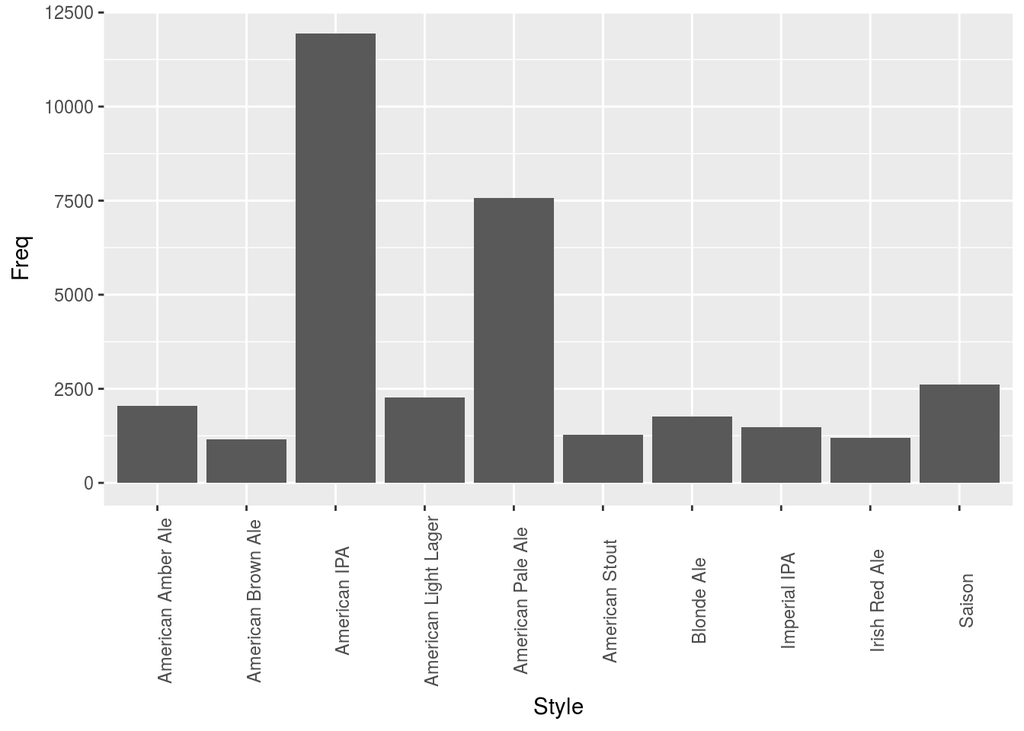

#### From the above plot we can see that American IPA’s are by the most popular recipe on Brewer’s Friend

## Beer and IBUs

IBU, stands for International Bittering Units and measures a beer’s bitterness. Bitterness is imparted by hops, during the brewing process. This table from https://en.wikipedia.org/wiki/Beer_measurement illustrates some of the most common beers and their IBU levels:

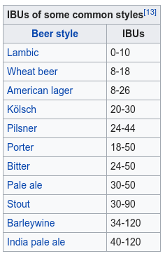

Out of 73,861 recipes we can see that the range for IBU is quite vast: 0 - 3409. By limiting the range of data for the boxplot we can better see the distribution of IBUs:

```
##    Min. 1st Qu.  Median    Mean 3rd Qu.    Max.
##    0.00   23.37   35.77   44.28   56.38 3409.00
```

```r
summary(df$ABV)
```

```
##    Min. 1st Qu.  Median    Mean 3rd Qu.    Max.
##   0.000   5.080   5.790   6.137   6.830  54.720
```

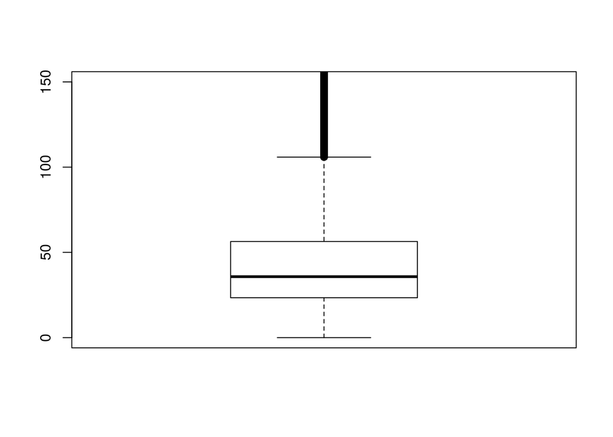

## Beer and ABV

ABV is the measurement of Alcohol by Volume. ABV is measured in ‘%’ and indicates what portion of the beer is alcohol. A higher ABV the stronger the beer. Of the 73,861 recipes we can see there is a pretty normal looking distribution. In the below plot the ABV has been limited to shorten the right tail.

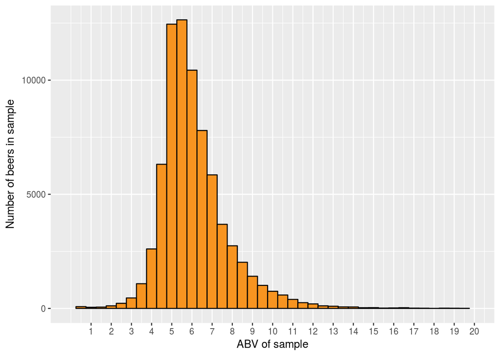

## ABV of The Most Popular Homebrew Style: American IPA

From the below distribution we can see that the most common ABV for American IPA is 6.5%.

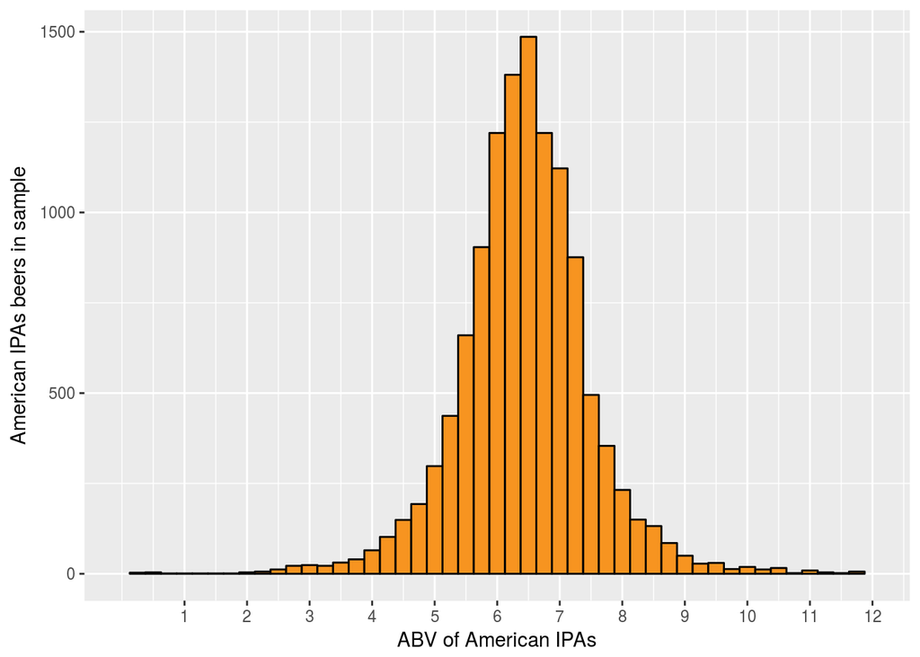